# Project: Investigate 'No Show for Appointments' Dataset

### Relationships and Correlations Stats

#### Q5. Is there a comination of factors cosidered a determinant for not showing up for appointments in Brazil?

```python
# Calculation time difference between scheduling and appointment day.
df['date_diff'] = pd.to_timedelta(df['AppointmentDay'] - df['ScheduledDay'], 'D')

# Extracting days from the scheduling and appointment date difference
df['date_diff'] = round(df['date_diff'] / np.timedelta64(1, 'D')).astype('int')
df['date_diff'].describe()
```

```
count    110526.000000
mean          9.803386
std          15.238548
min          -7.000000
25%           0.000000
50%           3.000000
75%          14.000000
max         179.000000
Name: date_diff, dtype: float64
```

The negative diffidence output is related to the same day or on-spot reservations, so all zero and negative date_diff data will be omitted.

```python
# Creating a new data frame without the zero and less date difference values.
df2 = df[df.date_diff > 0]
df2.describe()
```

|  | PatientId | AppointmentID | Age | Handicap | sch_month | sch_hour | app_month | date_diff |
| --- | --- | --- | --- | --- | --- | --- | --- | --- |
| count | 6.955500e+04 | 6.955500e+04 | 69555.000000 | 69555.000000 | 69555.000000 | 69555.000000 | 69555.000000 | 69555.000000 |
| mean | 1.455793e+14 | 5.653247e+06 | 38.441593 | 0.019740 | 4.599324 | 10.960175 | 5.211315 | 15.752972 |
| std | 2.538416e+14 | 7.494286e+04 | 22.893425 | 0.153174 | 0.741619 | 3.255970 | 0.477008 | 16.534314 |
| min | 3.921784e+04 | 5.030230e+06 | 0.000000 | 0.000000 | 1.000000 | 6.000000 | 4.000000 | 1.000000 |
| 25% | 3.967400e+12 | 5.616020e+06 | 19.000000 | 0.000000 | 4.000000 | 8.000000 | 5.000000 | 4.000000 |
| 50% | 2.999466e+13 | 5.659467e+06 | 39.000000 | 0.000000 | 5.000000 | 10.000000 | 5.000000 | 10.000000 |
| 75% | 9.384789e+13 | 5.705426e+06 | 57.000000 | 0.000000 | 5.000000 | 14.000000 | 5.000000 | 23.000000 |
| max | 9.999320e+14 | 5.782678e+06 | 115.000000 | 4.000000 | 12.000000 | 21.000000 | 6.000000 | 179.000000 |

```python
# Finding the difference between
# data frame 2 (without zero or less values) and data frame 1
df2.shape, df.shape, round(df2.shape[0] / df.shape[0] * 100, 2)
```

```
((69555, 21), (110526, 21), 62.93)
```

New data frame (without same day and on-spot reservations) constitutes of 62.93% of the original data frame appointments.

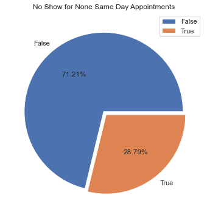

```python
# Displaying pie chart for general no show for appointments stats
# without same day and on-spot booked appointments.
pie_noshow = df2['no_show'].value_counts()
pie_noshow.plot.pie(figsize= (6,6), autopct='%.2f%%', explode=(0, .05))
plt.title('No Show for None Same Day Appointments')
plt.ylabel(None)
plt.legend()
plt.show()
```

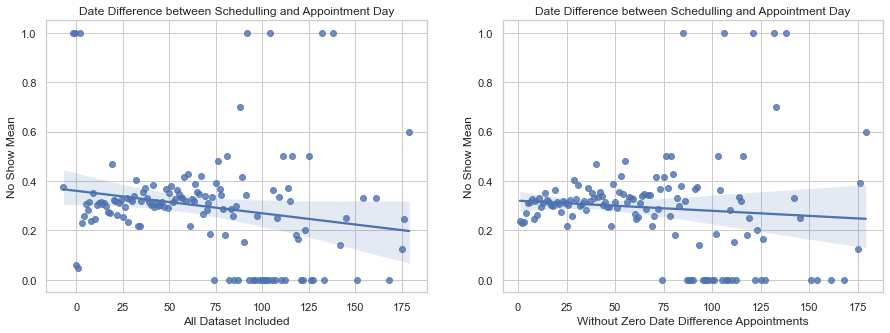

```
date_diff_categories  no_show
91-100                False      79.59
101-120               False      76.92
81-90                 False      75.81
161-180               False      75.56
0-10                  False      74.77
61-70                 False      72.07
11-20                 False      67.95
21-30                 False      67.32
41-50                 False      67.11
71-80                 False      66.82
51-60                 False      66.24
31-40                 False      65.35
121-140               False      65.00
141-160               True       55.00
                      False      45.00
121-140               True       35.00
31-40                 True       34.65
51-60                 True       33.76
71-80                 True       33.18
41-50                 True       32.89
21-30                 True       32.68
11-20                 True       32.05
61-70                 True       27.93
0-10                  True       25.23
161-180               True       24.44
81-90                 True       24.19
101-120               True       23.08
91-100                True       20.41
Name: AppointmentID, dtype: float64
```

```python
# Creating categories for difference between scheduling and appointment date.
bins = [0, 10, 20, 30, 40, 50, 60, 70, 80, 90, 100, 120, 140, 160, 180]
labels = ['0-10', '11-20', '21-30', '31-40', '41-50',
          '51-60', '61-70', '71-80', '81-90', '91-100',
          '101-120', '121-140', '141-160', '161-180']

df.loc[:, 'date_diff_categories'] = pd.cut(df2['date_diff'],
                                           bins= bins, labels= labels, include_lowest=True)

df['date_diff_categories'] = df.loc[:, 'date_diff_categories']

# Displaying appointments count based on difference between scheduling and appointment day
# for all data
plt.figure(figsize= (15, 5))
plt.subplot(1, 2, 1)
noshow_mean = df['no_show'].groupby(df['date_diff']).mean()
date_diff = df['date_diff'].unique()
sns.regplot(x = date_diff, y = noshow_mean)
plt.title('Date Difference between Schedulling and Appointment Day')
plt.xlabel('All Dataset Included')
plt.ylabel('No Show Mean')

# Displaying appointments count based on difference between scheduling and appointment day
# for data without zero date difference Appointments
plt.subplot(1, 2, 2)
noshow_mean = df2['no_show'].groupby(df2['date_diff']).mean()
date_diff = df2['date_diff'].unique()
sns.regplot(x = date_diff, y = noshow_mean)
plt.title('Date Difference between Schedulling and Appointment Day')
plt.xlabel('Without Zero Date Difference Appointments')
plt.ylabel('No Show Mean')
plt.show()

# Displaying proportions for the difference between scheduling and appointment day and appointment ID
counts = df.groupby(['date_diff_categories', 'no_show']).count()['AppointmentID']
totals = df.groupby(['date_diff_categories']).count()['AppointmentID']
proportions = counts / totals
round(proportions * 100, 2).sort_values(ascending= False)
```

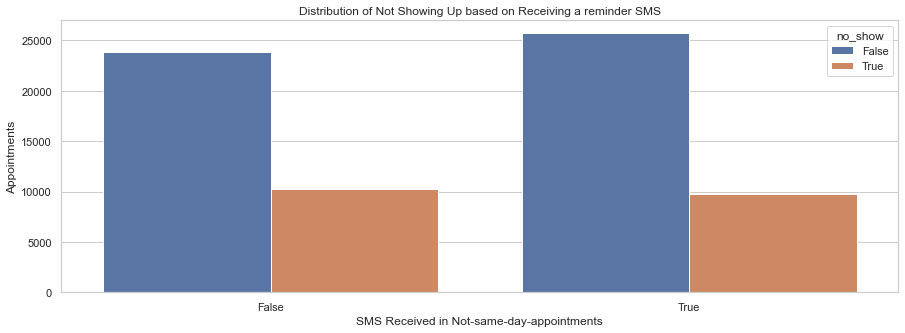

```
SMS_received  no_show
True          False      72.43
False         False      69.95
              True       30.05
True          True       27.57
Name: AppointmentID, dtype: float64
```

```python
# Displaying the relationship between receiving a reminder SMS and not showing up for appointments
# using the no zero difference day between scheduled and appointment day data frame
relation_figure(df2, 'SMS_received', 'no_show',
                'Distribution of Not Showing Up based on Receiving a reminder SMS',
                'SMS Received in Not-same-day-appointments', 'Appointments')

counts = df2.groupby(['SMS_received','no_show']).count()['AppointmentID']
totals = df2.groupby('SMS_received').count()['AppointmentID']
proportions = counts / totals
round(proportions * 100, 2).sort_values(ascending= False)
```

In data frame 2 (df2) where patients with same day or on-spot booking appointments were dropped, data shows that patients who did not receive a reminder SMS had no show rates more than patients who received a reminder SMS, 30.05% and 27.57% respectively.

```python
# Displaying relationship in proportions between gender, age categories and not showing up for appointments.
counts = df.groupby(['Gender', 'age_categories','no_show']).count()['AppointmentID']
totals = df.groupby(['Gender', 'age_categories']).count()['AppointmentID']
proportions = counts / totals
round(proportions * 100, 2).sort_values(ascending= False)
```

```
Gender  age_categories    no_show
M       centenarian       False      100.00
        youngest old      False       85.25
F       youngest old      False       84.67
M       middle old        False       84.35
F       middle old        False       84.27
M       old adult         False       83.40
F       oldest old        False       83.25
M       oldest old        False       82.65
F       old adult         False       82.52
        kid               False       78.32
M       kid               False       78.20
        middle-age adult  False       77.97
F       middle-age adult  False       77.47
        adolescent        False       75.07
M       young adult       False       74.82
F       young adult       False       74.76
M       adolescent        False       73.84
F       centenarian       False       66.67
                          True        33.33
M       adolescent        True        26.16
F       young adult       True        25.24
M       young adult       True        25.18
F       adolescent        True        24.93
        middle-age adult  True        22.53
M       middle-age adult  True        22.03
        kid               True        21.80
F       kid               True        21.68
        old adult         True        17.48
M       oldest old        True        17.35
F       oldest old        True        16.75
M       old adult         True        16.60
F       middle old        True        15.73
M       middle old        True        15.65
F       youngest old      True        15.33
M       youngest old      True        14.75
        centenarian       True         0.00
Name: AppointmentID, dtype: float64
```

```
Hypertension  Diabetes  no_show
True          False     False      82.82
              True      False      82.41
False         True      False      80.16
              False     False      79.08
                        True       20.92
              True      True       19.84
True          True      True       17.59
              False     True       17.18
Name: AppointmentID, dtype: float64
```

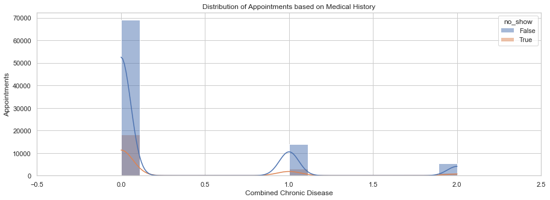

```python
# Combining hypertension and diabetes and its relation with not showing up for appointments.
df['chronic'] = np.add(df['Hypertension'], df['Diabetes'], dtype= np.float32)
plt.figure(figsize= (15, 5))
sns.histplot(data = df, x = 'chronic', hue= 'no_show', kde= True)
plt.xticks(np.arange(min(df['chronic']) - 0.5, max(df['chronic'])+1, 0.5))
plt.title('Distribution of Appointments based on Medical History')
plt.xlabel('Combined Chronic Disease')
plt.ylabel('Appointments');

counts = df.groupby(['Hypertension', 'Diabetes', 'no_show']).count()['AppointmentID']
totals = df.groupby(['Hypertension', 'Diabetes']).count()['AppointmentID']
proportions = counts / totals
round(proportions * 100, 2).sort_values(ascending= False)
```

Data frame shows that people with no history of hypertension of diabetes have the most no show rate with 20.92% of them not showing for their appointments.

```python
# Combining all chronic diseases  and its relation with not showing up for appointments.
counts = df.groupby(['Hypertension', 'Diabetes', 'Handicap', 'no_show']).count()['AppointmentID']
totals = df.groupby(['Hypertension', 'Diabetes', 'Handicap']).count()['AppointmentID']
proportions = counts / totals
round(proportions * 100, 2).sort_values(ascending= False)
```

```
Hypertension  Diabetes  Handicap  no_show
False         True      2         False      100.00
True          False     3         True       100.00
False         True      1         False       90.00
              False     2         False       85.71
True          True      1         False       85.13
              False     1         False       83.60
False         False     3         False       83.33
True          False     0         False       82.85
              True      0         False       82.28
                        2         False       80.95
False         False     1         False       80.16
              True      0         False       79.87
              False     0         False       79.06
                        4         False       66.67
True          False     2         False       64.29
                                  True        35.71
False         False     4         True        33.33
                        0         True        20.94
              True      0         True        20.13
              False     1         True        19.84
True          True      2         True        19.05
                        0         True        17.72
              False     0         True        17.15
False         False     3         True        16.67
True          False     1         True        16.40
              True      1         True        14.87
False         False     2         True        14.29
              True      1         True        10.00
Name: AppointmentID, dtype: float64
```

```python
# Displaying the correlation between not showing up for appointments and other variables
# in data without zero or less day difference between scheduling and appointment day.
df['no_show'].replace({'No': 0, 'Yes': 1}, inplace= True)
df2.corr()
```

|  | PatientId | AppointmentID | Age | Scholarship | Hypertension | Diabetes | Alcoholism | Handicap | SMS_received | no_show | sch_month | sch_hour | app_month | date_diff |
| --- | --- | --- | --- | --- | --- | --- | --- | --- | --- | --- | --- | --- | --- | --- |
| PatientId | 1.000000 | -0.002736 | -0.004521 | -0.002145 | -0.002676 | -0.000331 | 0.005801 | -0.003669 | -0.006891 | 0.003761 | -0.002532 | 0.003909 | 0.002451 | 0.005174 |
| AppointmentID | -0.002736 | 1.000000 | 0.017425 | 0.019108 | 0.042359 | 0.039926 | 0.025593 | 0.010591 | -0.061952 | -0.062904 | 0.783229 | -0.038427 | 0.472193 | -0.789292 |
| Age | -0.004521 | 0.017425 | 1.000000 | -0.103266 | 0.500123 | 0.284006 | 0.080361 | 0.075135 | -0.041356 | -0.102492 | 0.042708 | -0.024937 | 0.020934 | -0.005551 |
| Scholarship | -0.002145 | 0.019108 | -0.103266 | 1.000000 | -0.027639 | -0.025817 | 0.030758 | -0.010000 | 0.019571 | 0.046608 | 0.009841 | -0.011449 | -0.007252 | -0.028398 |
| Hypertension | -0.002676 | 0.042359 | 0.500123 | -0.027639 | 1.000000 | 0.424942 | 0.085314 | 0.082700 | -0.034695 | -0.057317 | 0.058915 | -0.041750 | 0.006733 | -0.048467 |
| Diabetes | -0.000331 | 0.039926 | 0.284006 | -0.025817 | 0.424942 | 1.000000 | 0.024605 | 0.061829 | -0.029571 | -0.023947 | 0.043023 | -0.018288 | 0.002139 | -0.046917 |
| Alcoholism | 0.005801 | 0.025593 | 0.080361 | 0.030758 | 0.085314 | 0.024605 | 1.000000 | 0.013396 | -0.008762 | 0.019660 | 0.019757 | -0.008594 | 0.004490 | -0.029270 |
| Handicap | -0.003669 | 0.010591 | 0.075135 | -0.010000 | 0.082700 | 0.061829 | 0.013396 | 1.000000 | -0.021106 | -0.007100 | 0.012799 | -0.004189 | 0.000367 | -0.014509 |
| SMS_received | -0.006891 | -0.061952 | -0.041356 | 0.019571 | -0.034695 | -0.029571 | -0.008762 | -0.021106 | 1.000000 | -0.027333 | -0.112278 | 0.030227 | 0.156589 | 0.176027 |
| no_show | 0.003761 | -0.062904 | -0.102492 | 0.046608 | -0.057317 | -0.023947 | 0.019660 | -0.007100 | -0.027333 | 1.000000 | -0.060640 | 0.038507 | -0.026771 | 0.055927 |
| sch_month | -0.002532 | 0.783229 | 0.042708 | 0.009841 | 0.058915 | 0.043023 | 0.019757 | 0.012799 | -0.112278 | -0.060640 | 1.000000 | -0.051395 | 0.444584 | -0.554855 |
| sch_hour | 0.003909 | -0.038427 | -0.024937 | -0.011449 | -0.041750 | -0.018288 | -0.008594 | -0.004189 | 0.030227 | 0.038507 | -0.051395 | 1.000000 | -0.036534 | 0.038083 |
| app_month | 0.002451 | 0.472193 | 0.020934 | -0.007252 | 0.006733 | 0.002139 | 0.004490 | 0.000367 | 0.156589 | -0.026771 | 0.444584 | -0.036534 | 1.000000 | 0.003981 |
| date_diff | 0.005174 | -0.789292 | -0.005551 | -0.028398 | -0.048467 | -0.046917 | -0.029270 | -0.014509 | 0.176027 | 0.055927 | -0.554855 | 0.038083 | 0.003981 | 1.000000 |

Data frame shows a moderate positive statistical correlation between age, hypertension (r= 0.5), and diabetes (r= 0.28), indicating an increase in hypertension and diabetes frequency with aging, and an increased diabetes frequency with hypertension (r= 0.42). Not showing for appointments had a weak negative statistical correlation with age (r= -0.1).

## Conclusions

### Research Questions answered:

Regarding scheduling or appointment time or date, scheduling an appointment in March, Friday or 9:00 PM had the highest chance of not showing up for appointments, while the appointment being in May or Saturday had the highest chance of not showing up for appointments.

In regards to socio-demographic characteristics, female centenarians, male adolescents, SANTOS DUMONT neighbourhood, no subscription to the Brazilian welfare program "Bolsa Familia", not having hypertension or diabetes, and patients with disabilities have the highest chance of not showing up for appointments. In addition, receiving a reminder SMS decreased the number of not showing up for appointments in none same-day and on-spot reservations.

### Final Conclusion

In conclusion, there is a 20% chance of not showing up for a scheduled appointment, almost a 29% chance of not showing up if the scheduling day is not the same as the appointment day. Data shows a slight effect from indicators for not showing up for appointments (like age, chronic diseases, and receiving a reminder SMS) however, its impact on a decision can't be established, which requires new parameters or more complete and accurate data entries for the current dataset. Dependent and Independent variables statistically correlate with a weak to moderarte correlation.